# Prediction model of house prices

Flow ID: 5

12/08/2019

```r
library(DataExplorer)
library(textir) ## needed to standardize the data
library(class) ## needed for knn
library(ggplot2) # visualization
library(ggthemes) # visualization
library(scales) # visualization
library(dplyr) # data manipulation
library(randomForest) # random forest
library(corrplot) # correlation
library(tidyverse)
library(caret)
library(mgcv)
library(glmnet)
library(rpart)
library(gam)
library(lmtest)
library(Metrics)
```

# Explore the Dataset —————————————————-

```r
Data <- read.csv("pricehouse.csv") #importing pricehouse csv.
str(Data) #To learn about the amount of observations and variables and what kind of variables the dataset contains.
```

```
## 'data.frame':    932 obs. of  9 variables:
##  $ Taxi_dist    : int  9796 8294 11001 8301 10510 6665 13153 5882 7495 8233 ...
##  $ Market_dist  : int  5250 8186 14399 11188 12629 5142 11869 9948 11589 7067 ...
##  $ Hospital_dist: int  10703 12694 16991 12289 13921 9972 17811 13315 13370 11400 ...
##  $ Carpet_area  : int  1659 1461 1340 1451 1770 1442 1542 1261 1090 1030 ...
##  $ Builtup_area : int  1961 1752 1609 1748 2111 1733 1858 1507 1321 1235 ...
##  $ Parking_type : Factor w/ 4 levels "Covered","No Parking",..: 4 3 3 1 3 4 2 4 3 4 ...
##  $ City_type    : Factor w/ 3 levels "CAT A","CAT B",..: 2 2 1 2 2 2 1 3 2 3 ...
##  $ Rainfall     : int  530 210 720 620 450 760 1030 1020 680 1130 ...
##  $ Price_house  : int  6649000 3982000 5401000 5373000 4662000 4526000 7224000 3772000 4631000 4415000 ...
```

```r
summary(Data)#Summary provides a useful description of the variables. It indicates if the data contains any missing values.
```

```
##    Taxi_dist      Market_dist    Hospital_dist    Carpet_area
##  Min.   :  146   Min.   : 1666   Min.   : 3227   Min.   :  775
##  1st Qu.: 6476   1st Qu.: 9354   1st Qu.:11302   1st Qu.: 1318
##  Median : 8230   Median :11161   Median :13163   Median : 1480
##  Mean   : 8230   Mean   :11019   Mean   :13072   Mean   : 1512
##  3rd Qu.: 9937   3rd Qu.:12670   3rd Qu.:14817   3rd Qu.: 1655
##  Max.   :20662   Max.   :20945   Max.   :23294   Max.   :24300
##  NA's   :13      NA's   :13      NA's   :1       NA's   :8
##   Builtup_area         Parking_type City_type      Rainfall
##  Min.   :  932   Covered     :188   CAT A:329   Min.   :-110.0
##  1st Qu.: 1583   No Parking  :145   CAT B:365   1st Qu.: 600.0
##  Median : 1774   Not Provided:227   CAT C:238   Median : 780.0
##  Mean   : 1795   Open        :372               Mean   : 785.6
##  3rd Qu.: 1982                                  3rd Qu.: 970.0
##  Max.   :12730                                  Max.   :1560.0
##  NA's   :15
##   Price_house
##  Min.   :    30000
##  1st Qu.:  4658000
##  Median :  5866000
##  Mean   :  6084695
##  3rd Qu.:  7187250
##  Max.   :150000000
##
```

```r
#The first five variables all contain missing values. Secondly, it can give an early indication of outliers.
#In this case, we see the variable Rainfall has atleast one outlier, because the minimum value is -110
#which in reality is impossible and needs to be solved.
```

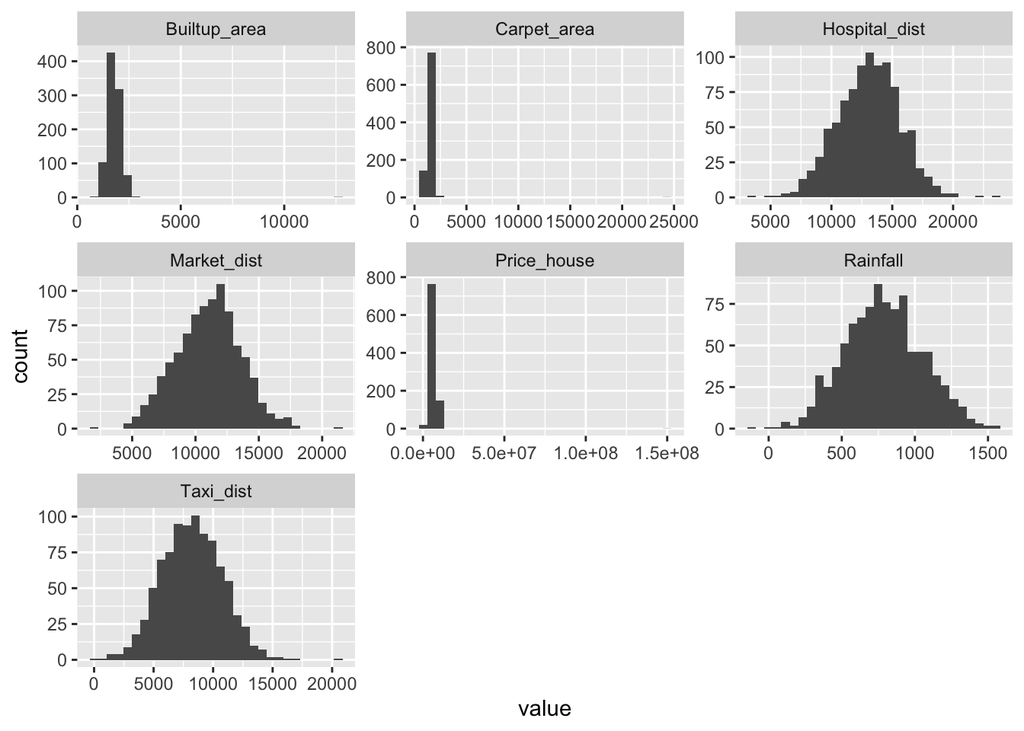

```r
#The next part is a plot of all the variables to get an idea of the distribution in terms of skewness.
Data %>%
  keep(is.numeric) %>%
  gather() %>%
  ggplot(aes(value)) +
  facet_wrap(~ key, scales = "free") +
  geom_histogram()
```

```r
#First of all the histogram shows the majority of the variables have potential outliers.
#Secondly, at least three of the variables are nonsymetric distributed due to outliers and should be symetric.
#It will be solved later on and tested again.
```

#Removal of Outliers.

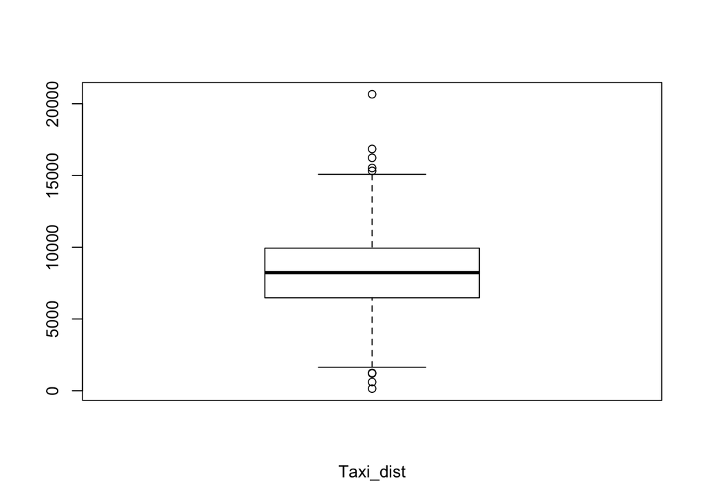

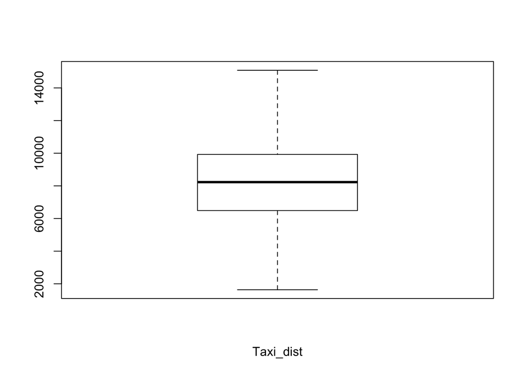

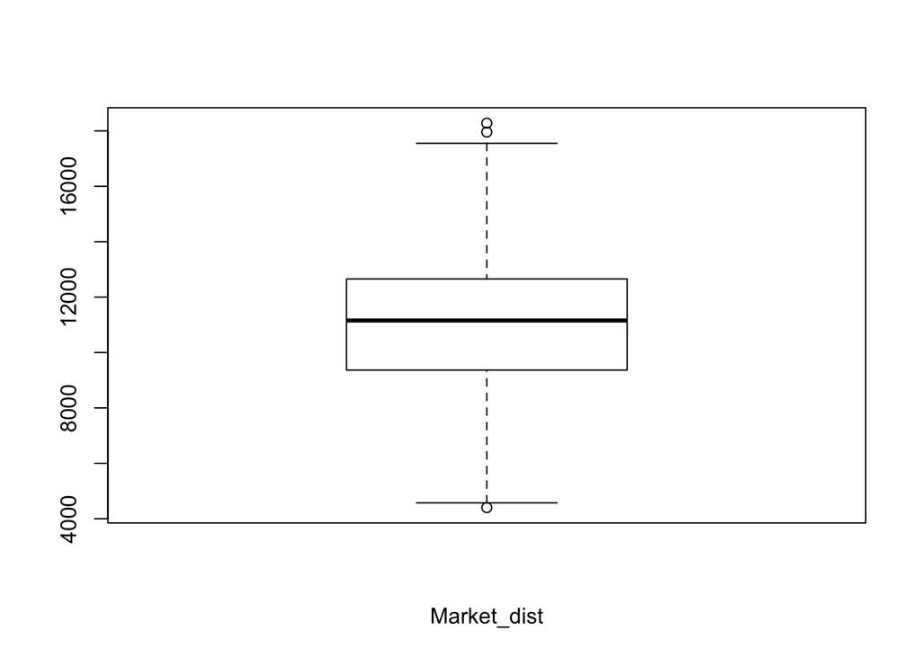

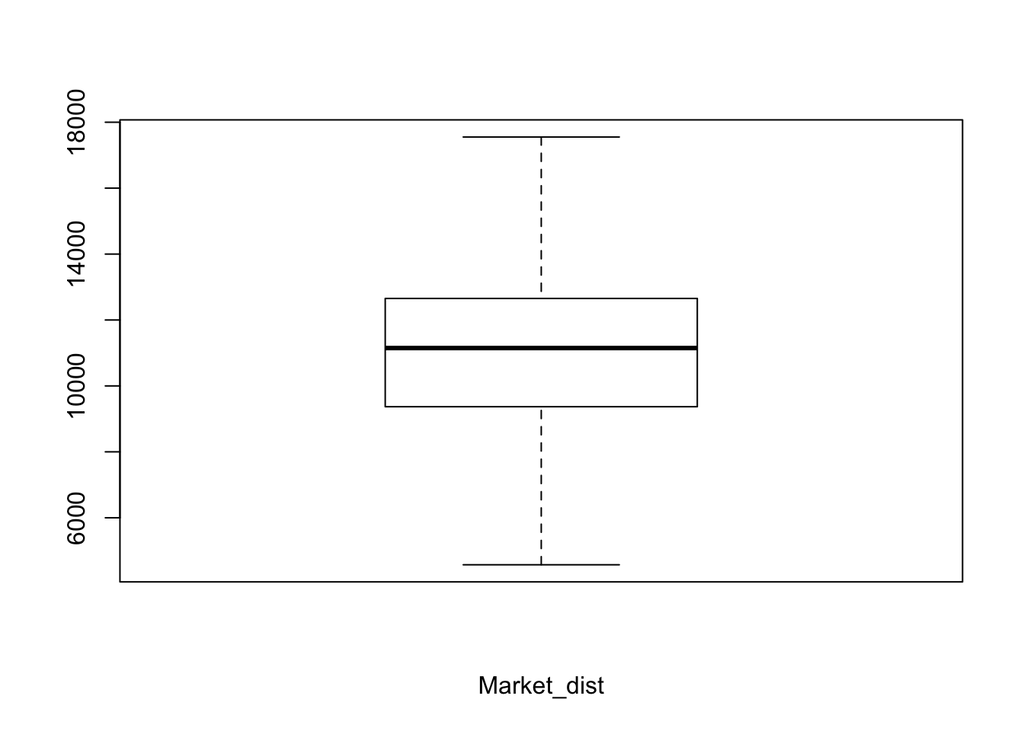

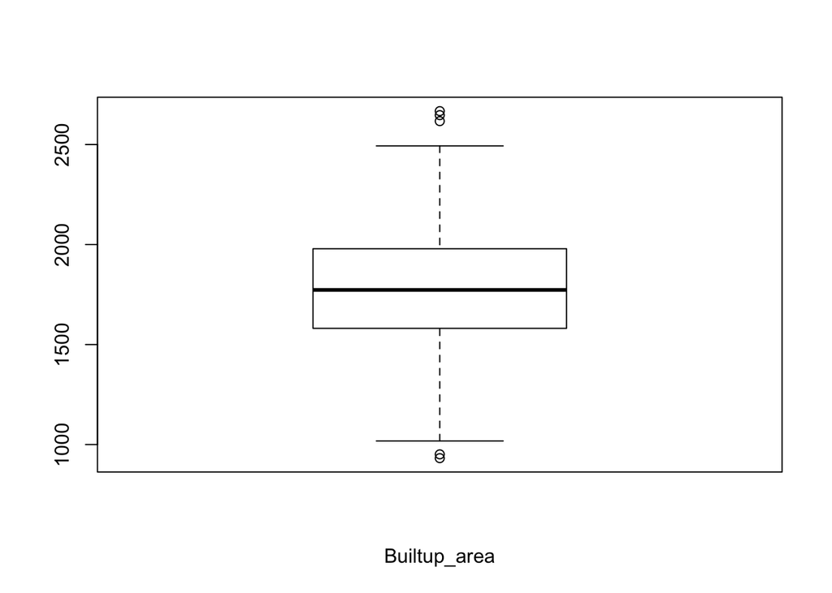

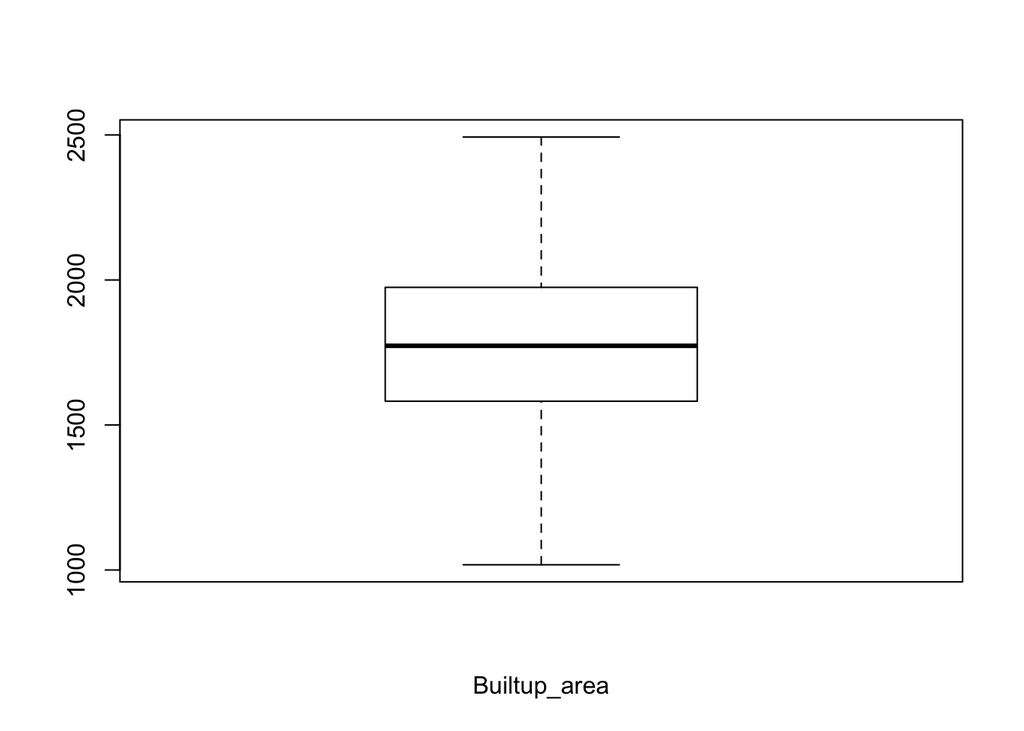

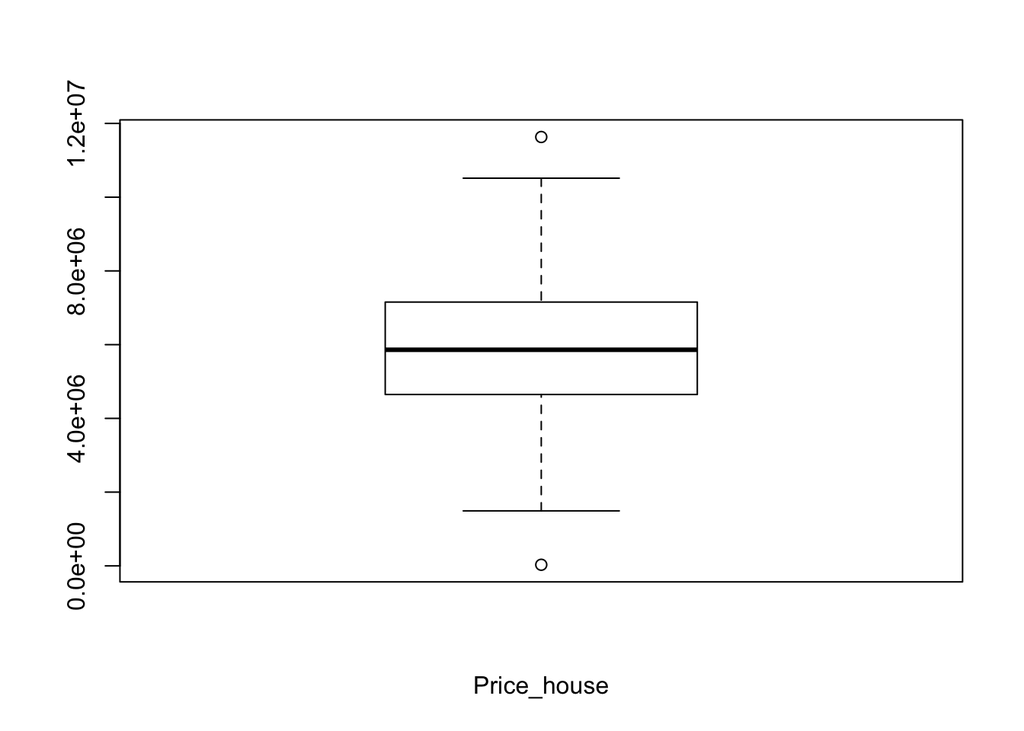

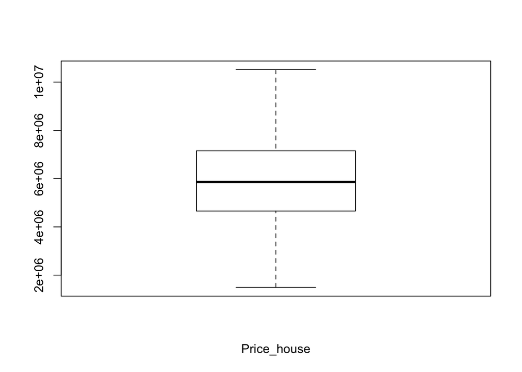

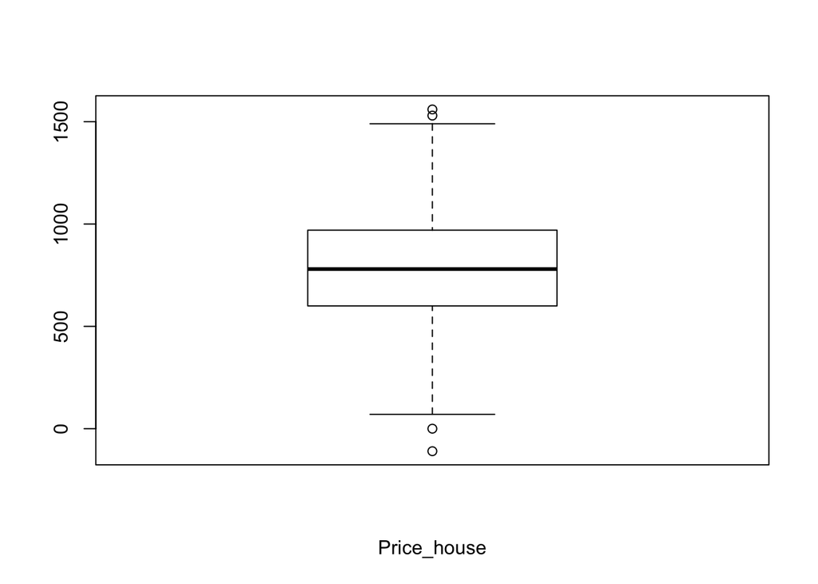

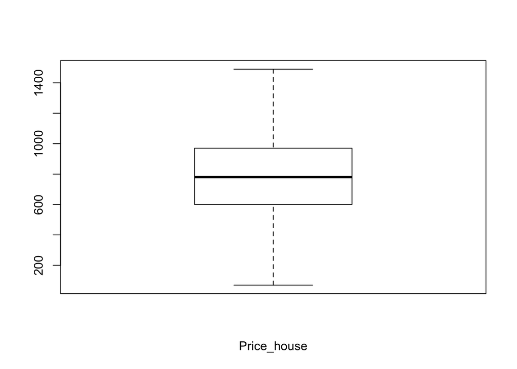

```r
{
    #The following code is used to find outliers, convert each outlier into a vector and then delete each observation which contain an outlier
    #We consider a value for an outlier, if the value is not within the first and third quantile.
    #A boxplot is used and will print each outlier

    boxplot(Data$Taxi_dist, xlab="Taxi_dist")$out
    #outliers: 1200 15522 20662 15321   604 16233 16850  1241   146 15082
    outliers.Taxi_dist <- boxplot(Data$Taxi_dist, plot=FALSE)$out #Assiging each outlier in Data to outliers.Taxi_dist
    Data[which(Data$Taxi_dist %in% outliers.Taxi_dist),] #Finding outliers in the dataset.
    Data <- Data[-which(Data$Taxi_dist %in% outliers.Taxi_dist),] #removing the outliers in the main dataset.
    boxplot(Data$Taxi_dist, xlab="Taxi_dist")

    #Same procedure for each variable.
    boxplot(Data$Market_dist, xlab="Market_dist")$out
    outliers.Market_dist <- boxplot(Data$Market_dist, plot=FALSE)$out
    Data[which(Data$Market_dist %in% outliers.Market_dist),]
    Data <- Data[-which(Data$Market_dist %in% outliers.Market_dist),]
    boxplot(Data$Market_dist, xlab="Market_dist")

    boxplot(Data$Builtup_area, xlab="Builtup_area")$out
    outliers.Builtup_area <- boxplot(Data$Builtup_area, plot=FALSE)$out
    Data[which(Data$Builtup_area %in% outliers.Builtup_area),]
    Data <- Data[-which(Data$Builtup_area %in% outliers.Builtup_area),]
    boxplot(Data$Builtup_area, xlab="Builtup_area")

    boxplot(Data$Price_house, xlab="Price_house")$out
    outliers.Price_house <- boxplot(Data$Price_house, plot=FALSE)$out
    Data[which(Data$Price_house %in% outliers.Price_house),]
    Data <- Data[-which(Data$Price_house %in% outliers.Price_house),]
    boxplot(Data$Price_house, xlab="Price_house")

    boxplot(Data$Rainfall, xlab="Price_house")$out
    outliers.Rainfall <- boxplot(Data$Rainfall, plot=FALSE)$out
    Data[which(Data$Rainfall %in% outliers.Rainfall),]
    Data <- Data[-which(Data$Rainfall %in% outliers.Rainfall),]
    boxplot(Data$Rainfall, xlab="Price_house")
}
```

A box plot of each variable was made. One before and after the outliers were removed.

#Removal of NAs

```r
#Before further exploration is made, the missing values need to be taken care of.
#Each missing value will be replaced by applying a mean value.
#The following code will solve the missing values for each variable.
{
    Data$Taxi_dist[is.na(Data$Taxi_dist)]=mean(Data$Taxi_dist,na.rm=T)
    Data$Market_dist[is.na(Data$Market_dist)]=round(mean(Data$Market_dist,na.rm=T),0)
    Data$Hospital_dist[is.na(Data$Hospital_dist)]=round(mean(Data$Hospital_dist,na.rm=T),0)
    Data$Carpet_area[is.na(Data$Carpet_area)]=round(mean(Data$Carpet_area,na.rm=T),0)
    Data$Builtup_area[is.na(Data$Builtup_area)]=round(mean(Data$Builtup_area,na.rm=T),0)
    apply(Data,2,function(x)sum(is.na(x))) #Used to check for missing values
}
```

```
##     Taxi_dist   Market_dist Hospital_dist   Carpet_area  Builtup_area
##             0             0             0             0             0
##  Parking_type     City_type      Rainfall   Price_house
##             0             0             0             0
```

#Correlation test

```r
#The next part is to check the data for potential correlation issues.
#To do that, each variable which has to be checked needs to be made numeric,
{
    Data$Parking_type <- as.numeric(Data$Parking_type) #Changing Parking_type from a factor to numeric.
    Data$City_type <- as.numeric(Data$City_type) # -.-
    Data$Rainfall <- as.numeric(Data$Rainfall) # -.-
    Data$Price_house <- as.numeric(Data$Price_house) # -.-
}
#Correlation test
{
    correlationMatrix <- cor(Data[,1:9])
    highlyCorrelated <- findCorrelation(correlationMatrix, cutoff=0.5)
    print(highlyCorrelated)
}
```

```
## [1] 3 4 9
```

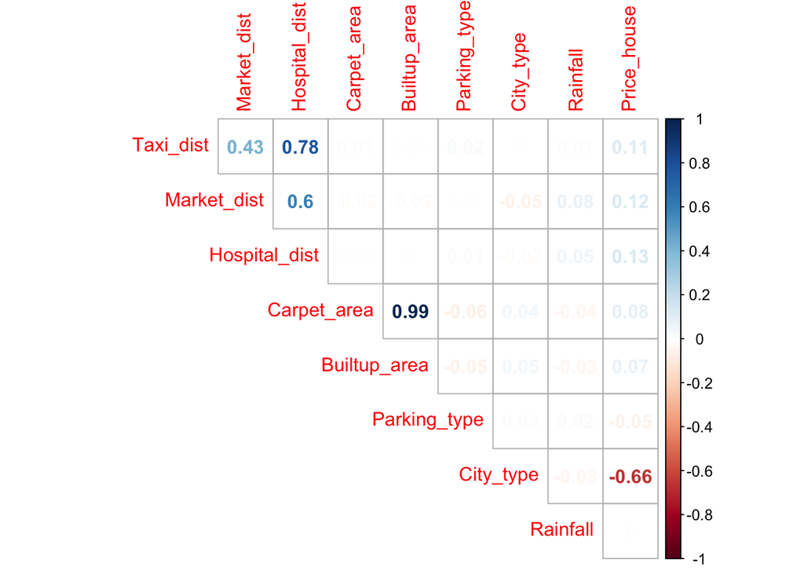

```r
#A userfriendly heatmap to indicate correlations.
corrplot(cor(Data), method = "number", type = "upper", diag = FALSE)
```

```r
#As mentioned earlier it is perfect normal that the price of a house and house price is correlated.
```

Taxi_dist and Hospital_Dist have a correlation of 0.78 but we will let be for now. A feature selection process will be conducted later on. Carpet-area and Builtup-area seems to suffer from multicollinearity. Carpet_area is a part of the total Builup_area. Carpet area will be removed from the dataset. Rainfall is not relevant and will also be deleted. There is no point in keeping unrelevant variables in the dataset.

```r
Data <- Data[ -c(4,8) ] #Removal of Carpet_area and Rainfall
#Data$Parking_type <- as.factor(Data$Parking_type) #Changing Parking_type from a numeric to factor
#Data$City_type <- as.factor(Data$City_type)#Changing Parking_type from a numeric to factor
```

# Test and Training set

```r
set.seed(123)#This seed will be used continously throughout the project.
#Partitioning of the the original dataset into test and train.
inTrain <- createDataPartition(y = Data$Price_house, p = 0.75, list = FALSE)
training <- Data[inTrain,]
testing <- Data[-inTrain,]
```

#Feature selection using regsubsets()

```r
library(leaps)
#reqsubsets is used to perform a selection of either forward or backward selection of features.
#In this case, only forward stepwise selection is being used.
reg.fit = regsubsets(training$Price_house ~ ., data = training, method = "forward")
reg.summary = summary(reg.fit)
reg.summary
```

```
## Subset selection object
## Call: regsubsets.formula(training$Price_house ~ ., data = training,
##     method = "forward")
## 6 Variables  (and intercept)
##               Forced in Forced out
## Taxi_dist         FALSE      FALSE
## Market_dist       FALSE      FALSE
## Hospital_dist     FALSE      FALSE
## Builtup_area      FALSE      FALSE
## Parking_type      FALSE      FALSE
## City_type         FALSE      FALSE
## 1 subsets of each size up to 6
## Selection Algorithm: forward
##          Taxi_dist Market_dist Hospital_dist Builtup_area Parking_type
## 1  ( 1 ) " "       " "         " "           " "          " "
## 2  ( 1 ) " "       " "         "*"           " "          " "
## 3  ( 1 ) " "       " "         "*"           "*"          " "
## 4  ( 1 ) " "       " "         "*"           "*"          "*"
## 5  ( 1 ) "*"       " "         "*"           "*"          "*"
## 6  ( 1 ) "*"       "*"         "*"           "*"          "*"
##          City_type
## 1  ( 1 ) "*"
## 2  ( 1 ) "*"
## 3  ( 1 ) "*"
## 4  ( 1 ) "*"
## 5  ( 1 ) "*"
## 6  ( 1 ) "*"
```

```r
summary(reg.fit)
```

```
## Subset selection object
## Call: regsubsets.formula(training$Price_house ~ ., data = training,
##     method = "forward")
## 6 Variables  (and intercept)
##               Forced in Forced out
## Taxi_dist         FALSE      FALSE
## Market_dist       FALSE      FALSE
## Hospital_dist     FALSE      FALSE
## Builtup_area      FALSE      FALSE
## Parking_type      FALSE      FALSE
## City_type         FALSE      FALSE
## 1 subsets of each size up to 6
## Selection Algorithm: forward
##          Taxi_dist Market_dist Hospital_dist Builtup_area Parking_type
## 1  ( 1 ) " "       " "         " "           " "          " "
## 2  ( 1 ) " "       " "         "*"           " "          " "
## 3  ( 1 ) " "       " "         "*"           "*"          " "
## 4  ( 1 ) " "       " "         "*"           "*"          "*"
## 5  ( 1 ) "*"       " "         "*"           "*"          "*"
## 6  ( 1 ) "*"       "*"         "*"           "*"          "*"
##          City_type
## 1  ( 1 ) "*"
## 2  ( 1 ) "*"
## 3  ( 1 ) "*"
## 4  ( 1 ) "*"
## 5  ( 1 ) "*"
## 6  ( 1 ) "*"
```

```r
#Preprocess of finding the most relevant variables. An adjusted r-square(adjr2) is used. The adjr2 is useful to see how each model fits to the dataset.
reg.summary$adjr2
```

```
## [1] 0.4256081 0.4405158 0.4472177 0.4480540 0.4486669 0.4486649
```

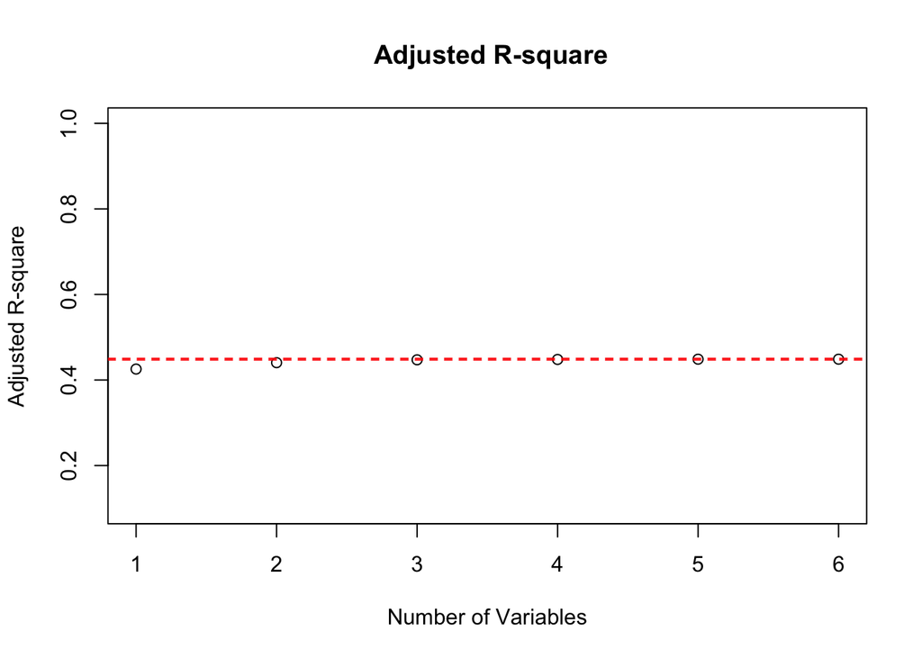

```r
#Plot used to see the optimal amount of variables which should be included in the later models.
plot(reg.summary$adjr2, xlab = "Number of Variables", ylab = "Adjusted R-square", type = "p", ylim = c(0.1, 1), main = " Adjusted R-square")
max.adjr2 = max(reg.summary$adjr2) #maximum adjusted r-square
std.adjr2 = sd(reg.summary$adjr2) #standard deviation
abline(h = max.adjr2 + 0.2 * std.adjr2, col = "red", lty = 2)#used to find the score which is within 0.2 std. deviations away
abline(h = max.adjr2 - 0.2 * std.adjr2, col = "red", lty = 2)
```

The optimal amount of variables are 3 to 4 but we decided to go with 3 in the case.

```r
#Used to find the most important variables to predict the dependt variable.
reg.fit = regsubsets(training$Price_house ~ ., data = training, method = "forward")
coefi = coef(reg.fit, id=3) #The number three was found in the previous part.
names(coefi) #List the three variables, which we will used in the different models.
```

```
## [1] "(Intercept)"   "Hospital_dist" "Builtup_area"  "City_type"
```

The most important variables are “Hospital_dist” “Builtup_area” “City_type”